# 每週一圖作業繪圖說明檔

#### 環境設定

以下為老師執行時一定會存在的環境設定

```r
rm(list=ls())
library(dplyr); library(stringr); library(ggplot2); library(plotly); library(lubridate); library(readr); library(colorspace); library(grDevices); library(shiny); library(shinyjs); library(scales)
library(tidyr); library(showtext); library(tidyverse); library(colorspace)

#font_add("QYuan","cwTeXQYuan-Medium.ttf") # 新增字體
showtext_auto(enable=TRUE) #啟用字體
theme_set(theme_classic())
knitr::opts_chunk$set(fig.align='center', fig.showtext=T)
```

#### 繪圖程式

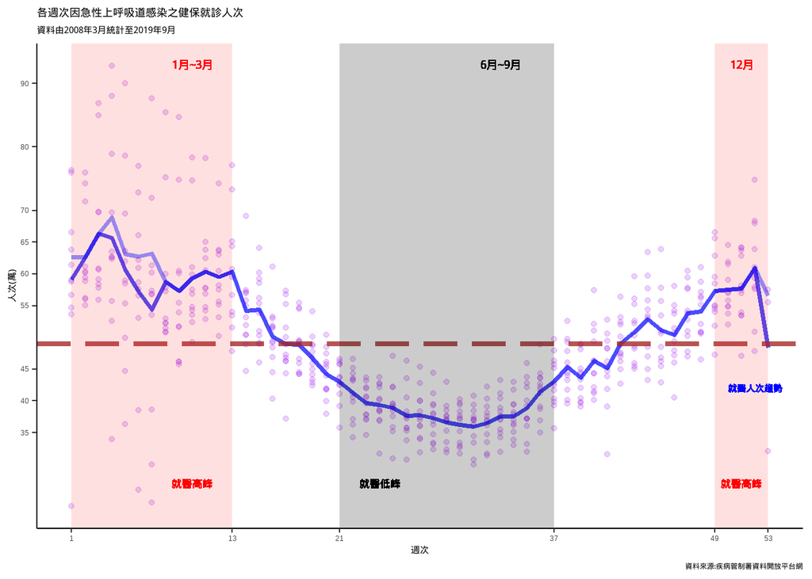

```r
load("graphData.Rda")


graphData$InfectedPeople%>%
  ggplot()+
  geom_point(color="purple",alpha=0.2,
    aes(x=週次,y=人次)
  )+
  geom_line(
    data = graphData$averagePeople,
    mapping =
      aes(x=週次,y=平均人次),
    color="blue",alpha=0.7,size=1.3
  )+ #-------------------------------original^
  scale_y_continuous(name = "人次(萬)", breaks = YBreakPeople,labels=YLabel)+
  geom_hline(yintercept = MeanPeople,color="brown",linetype="longdash",size=1.5,alpha=0.8
             )+ #--------------------A^
  geom_rect(
    data = graphData$Rect_high,
    mapping = aes(
      xmin=xstart,
      xmax=xend,
      ymin=ymin,
      ymax=ymax
    ),fill="red",alpha=0.12
  )+
  geom_rect(
    data = graphData$Rect_Low,
    mapping = aes(
      xmin=xstart,
      xmax=xend,
      ymin=ymin,
      ymax=ymax
    ),fill="black",alpha=0.2
  )+#--------------------------------B^
  geom_text(x=10,y=930000,label="1月~3月",color="red",size=5)+
  geom_text(x=33,y=930000,label="6月~9月",color="black",size=5)+
  geom_text(x=51,y=930000,label="12月",color="red",size=5)+
  geom_text(x=52,y=420000,label="就醫人次趨勢",color="blue")+
  geom_text(x=24,y=270000,label="就醫低峰",color="black",size=4.5)+
  geom_text(x=10,y=270000,label="就醫高峰",color="red",size=4.5)+
  geom_text(x=51,y=270000,label="就醫高峰",color="red",size=4.5
            )+ #---------------------C^
  scale_x_continuous(breaks = XBreak
                     )+#-------------D^
  labs(
    title = "各週次因急性上呼吸道感染之健保就診人次",
    subtitle = "資料由2008年3月統計至2019年9月",
    caption = "資料來源:疾病管制署資料開放平台網"
    )+#------------------------------E^
  geom_line(
    data = graphData$averagePeople_fixed1,
    mapping =
      aes(x=週次,y=平均人次),
    color="blue",alpha=0.4,size=1.3
  )+
  geom_line(
    data = graphData$averagePeople_fixed2,
    mapping =
      aes(x=週次,y=平均人次),
    color="blue",alpha=0.4,size=1.3
  )#---------------------------------F^
```

#### 設計說明

說明想傳達的訊息（必要）及設計想法（非必要）。寫在***下一行。

深藍色實線為各週次，在不同年份中的人次平均值所連成的軌跡，觀察其將能看出就醫人次趨勢。

由藍色的趨勢線，我們可以發現，**週次**與**就醫人次**是**有關聯**的:

1.第21到37週次，也就是每年的**6月到9月**時，就醫人次普遍較低，為**就醫低峰**,

2.每年的第1到13、第49到53週次，也就是**12月到隔年3月**，就醫人次普遍偏高，為**就醫高峰**。

由於在就醫高峰之中有幾筆資料不尋常的低，將其刪去後，`修正後的趨勢線以較淡的藍色表示`。

另外，觀察各點的分布情形，我們可以得知:

1.在**就醫低峰**期間，**就醫人次較為接近**,

2.在**就醫高峰**期間，**各年就醫人次差異較大**。

/

設計想法: 原本的設計(`折線圖`)能明顯看出就醫人次呈現**週期性變化**，也能**詳細觀察各年的變化**，但是其他資訊較為不直觀。而且隨著資料量的增加，圖形將越來越長，屆時一眼能看到的資訊僅有週期性。

把圖形轉成`散佈圖`後，即將年份的資訊捨棄，圖形中*看不出來各年的詳細變化情況*。但`散佈圖`有以下**優點**:

1.**圖形不會因為資料量的增加而變長**,

2.更能將重點擺在**週次與就醫人次的關係**，而非各年的詳細變化情況,

3.更直觀看出**在相同週次，不同年間的人次差異大小**。

因此選擇改用`散佈圖`。